# Pharmacy First

## Methods

This study used data from OpenSAFELY-TPP, which covers 40% of the population of England. For a description of the representativeness of this sample, please see our manuscript [here](https://wellcomeopenresearch.org/articles/7-191/v1). Individuals were included if they were alive and registered at a TPP practice each month, across the study period. Patients were excluded if their listed age was not between 0 and 120 years.

Counts represent patients with at least one clinical code of relevance in that month. Patients with more than one of the same clinical code in a month were only counted once. Rates divide the count by the included study population and multiply by 1,000 to achieve a rate per 1,000 registered patients.

Counts <=7 have been redacted and all numbers rounded to the nearest 5 to avoid potential re-identification of individuals. The rates displayed were computed with these rounded counts.

Our data relies on a relevant Pharmacy First code being added to a patient’s GP record. The Pharmacy First service relies on [GP Connect: Update Record](https://digital.nhs.uk/services/gp-connect/gp-connect-in-your-organisation/gp-connect-update-record) to update a patient’s GP record with consultation information from the community pharmacy. Following the launch of the Pharmacy First service, there has been a [gradual roll-out of GP Connect: Update Record](https://cpe.org.uk/our-news/gp-connect-update-record-rollout-and-flow-of-information/) across the approved community pharmacy IT system suppliers.

This report contains the following sections:

- Clinical Services
- Clinical Pathways
  - Clinical condition
  - Days of the week
  - NHS region
  - Ethnicity
  - IMD
  - Shingles
    - Sex
    - Age
    - Ethnicity
    - IMD
    - Region
    - Medication supply
  - Urinary tract infection etc.
- Hypertension
  - Age
  - Sex
  - Region
- Contraception
  - Age
  - Region

## Clinical Services

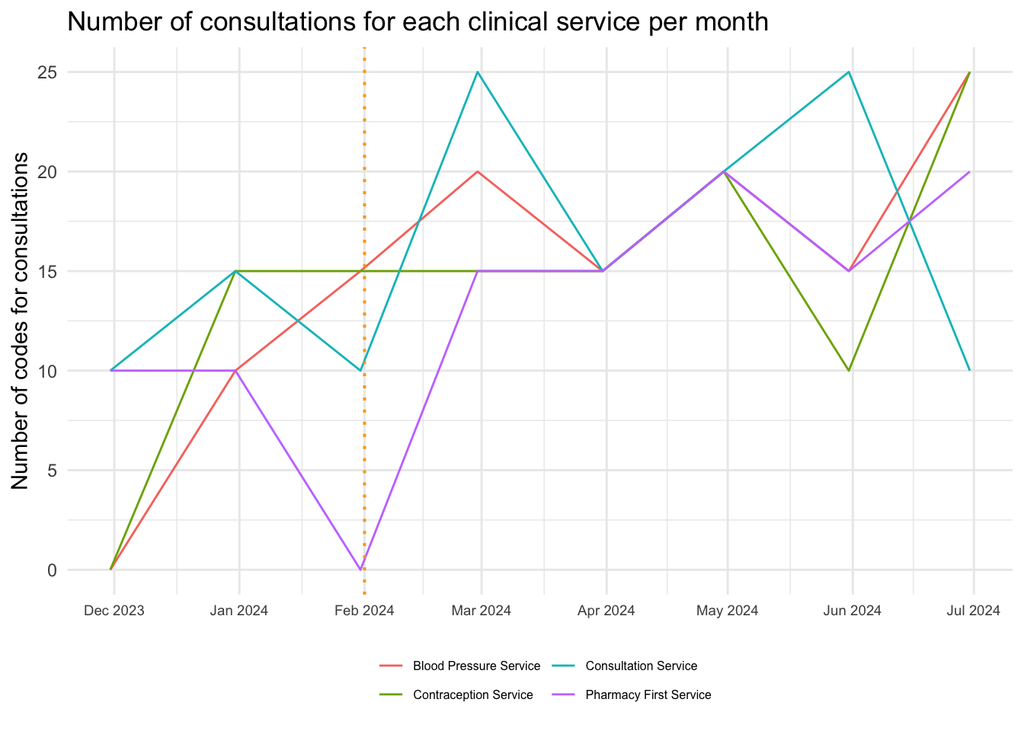